# UseCase_3

```python
# Importing libraries

import pandas as pd
import numpy as np
import matplotlib.pyplot as plt
import seaborn as sns
```

```python
# Load csv file

df=pd.read_csv('building_energy_data.csv')
```

```python
# Taking look at the data by Top 10 rows

df.head(10)
```

|  | BuildingID | BuildingSize | BuildingAge | InsulationType | Temperature | Humidity | EnergyConsumption | SupplierLeadTime | RenewableEnergySource |
| --- | --- | --- | --- | --- | --- | --- | --- | --- | --- |
| 0 | B0001 | 910 | 51 | Poor | 35.347140 | 14.848393 | 136.438375 | 23 | NaN |
| 1 | B0002 | 3822 | 54 | Fair | -3.381381 | 64.831627 | 270.517752 | 10 | Solar |
| 2 | B0003 | 3142 | 24 | Poor | 19.650725 | 11.997298 | 310.402460 | 11 | NaN |
| 3 | B0004 | 516 | 25 | Good | 19.956029 | 23.714734 | 70.034617 | 6 | Solar |
| 4 | B0005 | 4476 | 71 | Good | 7.673037 | 46.286320 | 412.368667 | 6 | NaN |
| 5 | B0006 | 3494 | 52 | Excellent | 12.923321 | 46.389795 | 467.748744 | 27 | Solar |
| 6 | B0007 | 3221 | 70 | Fair | -8.100922 | 64.856043 | 418.564823 | 9 | NaN |
| 7 | B0008 | 2969 | 88 | Excellent | 27.293002 | 82.817043 | 369.119427 | 15 | NaN |
| 8 | B0009 | 180 | 33 | Excellent | 17.466124 | 61.122573 | 62.286108 | 2 | Wind |
| 9 | B0010 | 1735 | 49 | Fair | -7.112947 | 86.282808 | 187.849783 | 4 | Solar |

```python
# The shape of the dataframe

df.shape
```

```
(1000, 9)
```

```python
# The index of the dataframe

df.index
```

```
RangeIndex(start=0, stop=1000, step=1)
```

```python
# The column names used

df.columns
```

```
Index(['BuildingID', 'BuildingSize', 'BuildingAge', 'InsulationType',
       'Temperature', 'Humidity', 'EnergyConsumption', 'SupplierLeadTime',
       'RenewableEnergySource'],
      dtype='object')
```

```python
# Copying the dataset into another variable, to use and make changes, by not affecting the original dataset

energy_data=df.copy()
print(energy_data)
```

```
    BuildingID  BuildingSize  BuildingAge InsulationType  Temperature  \
0        B0001           910           51           Poor    35.347140
1        B0002          3822           54           Fair    -3.381381
2        B0003          3142           24           Poor    19.650725
3        B0004           516           25           Good    19.956029
4        B0005          4476           71           Good     7.673037
..         ...           ...          ...            ...          ...
995      B0996          3331           41           Fair     0.208328
996      B0997           524           89           Good    -7.882886
997      B0998           467           48           Poor    18.986308
998      B0999          3650           13      Excellent    12.645554
999      B1000          1004           73           Good    37.437220

      Humidity  EnergyConsumption  SupplierLeadTime RenewableEnergySource
0    14.848393         136.438375                23                   NaN
1    64.831627         270.517752                10                 Solar
2    11.997298         310.402460                11                   NaN
3    23.714734          70.034617                 6                 Solar
4    46.286320         412.368667                 6                   NaN
..         ...                ...               ...                   ...
995  71.513604         297.239697                23                   NaN
996  89.526532         110.995530                27                 Solar
997  10.886284          58.407917                21                  Wind
998  68.413876         479.146987                16                  Wind
999  55.743145         121.846910                 9                 Solar

[1000 rows x 9 columns]
```

```python
# Assign all columns to a variable list

col=list(energy_data)
print(col)
```

```
['BuildingID', 'BuildingSize', 'BuildingAge', 'InsulationType', 'Temperature', 'Humidity', 'EnergyConsumption', 'SupplierLeadTime', 'RenewableEnergySource']
```

```python
# Taking look at the data by Top 10 rows

energy_data.head(21)
```

|  | BuildingID | BuildingSize | BuildingAge | InsulationType | Temperature | Humidity | EnergyConsumption | SupplierLeadTime | RenewableEnergySource |
| --- | --- | --- | --- | --- | --- | --- | --- | --- | --- |
| 0 | B0001 | 910 | 51 | Poor | 35.347140 | 14.848393 | 136.438375 | 23 | NaN |
| 1 | B0002 | 3822 | 54 | Fair | -3.381381 | 64.831627 | 270.517752 | 10 | Solar |
| 2 | B0003 | 3142 | 24 | Poor | 19.650725 | 11.997298 | 310.402460 | 11 | NaN |
| 3 | B0004 | 516 | 25 | Good | 19.956029 | 23.714734 | 70.034617 | 6 | Solar |
| 4 | B0005 | 4476 | 71 | Good | 7.673037 | 46.286320 | 412.368667 | 6 | NaN |
| 5 | B0006 | 3494 | 52 | Excellent | 12.923321 | 46.389795 | 467.748744 | 27 | Solar |
| 6 | B0007 | 3221 | 70 | Fair | -8.100922 | 64.856043 | 418.564823 | 9 | NaN |
| 7 | B0008 | 2969 | 88 | Excellent | 27.293002 | 82.817043 | 369.119427 | 15 | NaN |
| 8 | B0009 | 180 | 33 | Excellent | 17.466124 | 61.122573 | 62.286108 | 2 | Wind |
| 9 | B0010 | 1735 | 49 | Fair | -7.112947 | 86.282808 | 187.849783 | 4 | Solar |
| 10 | B0011 | 819 | 29 | Excellent | 24.037795 | 80.529251 | 94.349329 | 5 | NaN |
| 11 | B0012 | 2441 | 63 | Fair | 13.339104 | 56.759984 | 338.620783 | 17 | Wind |
| 12 | B0013 | 2483 | 22 | Fair | -8.276937 | 76.703356 | 205.544190 | 8 | Solar |
| 13 | B0014 | 1234 | 26 | Good | 38.480386 | 61.406209 | 151.066979 | 8 | Solar |
| 14 | B0015 | 4605 | 28 | Fair | 37.455607 | 16.284626 | 375.004383 | 22 | NaN |
| 15 | B0016 | 3435 | 85 | Good | 15.645121 | 69.245178 | 261.561236 | 12 | Solar |
| 16 | B0017 | 4167 | 49 | Good | -5.316379 | 17.592675 | 561.718797 | 21 | Wind |
| 17 | B0018 | 4893 | 71 | Good | 27.731061 | 57.526622 | 410.385601 | 8 | Wind |
| 18 | B0019 | 2954 | 81 | Fair | 14.596555 | 66.211216 | 346.561351 | 19 | NaN |
| 19 | B0020 | 524 | 84 | Good | 5.122374 | 15.322209 | 61.885273 | 3 | NaN |
| 20 | B0021 | 1132 | 49 | Good | 14.570909 | 28.463572 | 165.465833 | 18 | NaN |

```python
# Check null values

energy_data.isnull().sum()
```

```
BuildingID                 0
BuildingSize               0
BuildingAge                0
InsulationType             0
Temperature                0
Humidity                   0
EnergyConsumption          0
SupplierLeadTime           0
RenewableEnergySource    321
dtype: int64
```

```python
# Filling Null Values in Renewable Energy Source using 'None'

energy_data.loc[:, 'RenewableEnergySource']=energy_data['RenewableEnergySource'].fillna('None')
```

```python
# Check null values

energy_data.isnull().sum()
```

```
BuildingID               0
BuildingSize             0
BuildingAge              0
InsulationType           0
Temperature              0
Humidity                 0
EnergyConsumption        0
SupplierLeadTime         0
RenewableEnergySource    0
dtype: int64
```

```python
# Taking look at the data by Top 10 rows

energy_data.head(21)
```

|  | BuildingID | BuildingSize | BuildingAge | InsulationType | Temperature | Humidity | EnergyConsumption | SupplierLeadTime | RenewableEnergySource |
| --- | --- | --- | --- | --- | --- | --- | --- | --- | --- |
| 0 | B0001 | 910 | 51 | Poor | 35.347140 | 14.848393 | 136.438375 | 23 | None |
| 1 | B0002 | 3822 | 54 | Fair | -3.381381 | 64.831627 | 270.517752 | 10 | Solar |
| 2 | B0003 | 3142 | 24 | Poor | 19.650725 | 11.997298 | 310.402460 | 11 | None |
| 3 | B0004 | 516 | 25 | Good | 19.956029 | 23.714734 | 70.034617 | 6 | Solar |
| 4 | B0005 | 4476 | 71 | Good | 7.673037 | 46.286320 | 412.368667 | 6 | None |
| 5 | B0006 | 3494 | 52 | Excellent | 12.923321 | 46.389795 | 467.748744 | 27 | Solar |
| 6 | B0007 | 3221 | 70 | Fair | -8.100922 | 64.856043 | 418.564823 | 9 | None |
| 7 | B0008 | 2969 | 88 | Excellent | 27.293002 | 82.817043 | 369.119427 | 15 | None |
| 8 | B0009 | 180 | 33 | Excellent | 17.466124 | 61.122573 | 62.286108 | 2 | Wind |
| 9 | B0010 | 1735 | 49 | Fair | -7.112947 | 86.282808 | 187.849783 | 4 | Solar |
| 10 | B0011 | 819 | 29 | Excellent | 24.037795 | 80.529251 | 94.349329 | 5 | None |
| 11 | B0012 | 2441 | 63 | Fair | 13.339104 | 56.759984 | 338.620783 | 17 | Wind |
| 12 | B0013 | 2483 | 22 | Fair | -8.276937 | 76.703356 | 205.544190 | 8 | Solar |
| 13 | B0014 | 1234 | 26 | Good | 38.480386 | 61.406209 | 151.066979 | 8 | Solar |
| 14 | B0015 | 4605 | 28 | Fair | 37.455607 | 16.284626 | 375.004383 | 22 | None |
| 15 | B0016 | 3435 | 85 | Good | 15.645121 | 69.245178 | 261.561236 | 12 | Solar |
| 16 | B0017 | 4167 | 49 | Good | -5.316379 | 17.592675 | 561.718797 | 21 | Wind |
| 17 | B0018 | 4893 | 71 | Good | 27.731061 | 57.526622 | 410.385601 | 8 | Wind |
| 18 | B0019 | 2954 | 81 | Fair | 14.596555 | 66.211216 | 346.561351 | 19 | None |
| 19 | B0020 | 524 | 84 | Good | 5.122374 | 15.322209 | 61.885273 | 3 | None |
| 20 | B0021 | 1132 | 49 | Good | 14.570909 | 28.463572 | 165.465833 | 18 | None |

```python
# Check for duplicates

duplicates = energy_data.duplicated()
number_duplicates = duplicates.sum()
print(number_duplicates)
```

```
0
```

```python
# Display entire information of the dataframe

energy_data.info()
```

```
<class 'pandas.core.frame.DataFrame'>
RangeIndex: 1000 entries, 0 to 999
Data columns (total 9 columns):
 #   Column                 Non-Null Count  Dtype
---  ------                 --------------  -----
 0   BuildingID             1000 non-null   object
 1   BuildingSize           1000 non-null   int64
 2   BuildingAge            1000 non-null   int64
 3   InsulationType         1000 non-null   object
 4   Temperature            1000 non-null   float64
 5   Humidity               1000 non-null   float64
 6   EnergyConsumption      1000 non-null   float64
 7   SupplierLeadTime       1000 non-null   int64
 8   RenewableEnergySource  1000 non-null   object
dtypes: float64(3), int64(3), object(3)
memory usage: 70.4+ KB
```

```python
# Convert attribute target from numerical values into categorical values

def insulationTypes(insulationtype):
    if insulationtype == 'Poor':
        return 0
    elif insulationtype == 'Fair':
        return 1
    elif insulationtype == 'Good':
        return 2
    elif insulationtype == 'Excellent':
        return 3

# Add them to the dataframe

energy_data['InsulationType_Category'] = energy_data['InsulationType'].apply(insulationTypes)
```

```python
# Convert attribute target from numerical values into categorical values

def renewableEnergySource(renewableenergysource):
    if renewableenergysource == 'None':
        return 0
    elif renewableenergysource == 'Solar':
        return 1
    elif renewableenergysource == 'Wind':
        return 2

# Add them to the dataframe

energy_data['Renewable_EnergySource_Category'] = energy_data['RenewableEnergySource'].apply(renewableEnergySource)
```

```python
# Descriptive Statistics

energy_data.describe()
```

|  | BuildingSize | BuildingAge | Temperature | Humidity | EnergyConsumption | SupplierLeadTime | Renewable_EnergySource_Category | InsulationType_Category |
| --- | --- | --- | --- | --- | --- | --- | --- | --- |
| count | 1000.000000 | 1000.000000 | 1000.000000 | 1000.000000 | 1000.000000 | 1000.000000 | 1000.000000 | 1000.000000 |
| mean | 2578.250000 | 50.149000 | 15.902084 | 49.384810 | 296.190255 | 14.646000 | 0.984000 | 1.475000 |
| std | 1390.960625 | 28.855874 | 14.235700 | 23.318803 | 162.629420 | 8.362692 | 0.791436 | 1.027829 |
| min | 53.000000 | 1.000000 | -9.977861 | 10.014922 | 27.606296 | 1.000000 | 0.000000 | 0.000000 |
| 25% | 1389.500000 | 26.000000 | 4.136905 | 28.924968 | 166.374887 | 8.000000 | 0.000000 | 1.000000 |
| 50% | 2647.000000 | 49.000000 | 16.586662 | 49.393253 | 273.275106 | 14.500000 | 1.000000 | 1.000000 |
| 75% | 3693.250000 | 75.250000 | 28.069674 | 70.030764 | 403.408926 | 22.000000 | 2.000000 | 2.000000 |
| max | 4998.000000 | 99.000000 | 39.977196 | 89.809826 | 742.628282 | 29.000000 | 2.000000 | 3.000000 |

```python
# Drop old numerical/categorical columns if no longer needed

energy_data.drop(columns=['BuildingID'], inplace=True)
```

```python
# Taking look at the data by Top 10 rows

energy_data.head(10)
```

|  | BuildingSize | BuildingAge | InsulationType | Temperature | Humidity | EnergyConsumption | SupplierLeadTime | RenewableEnergySource | Renewable_EnergySource_Category | InsulationType_Category |
| --- | --- | --- | --- | --- | --- | --- | --- | --- | --- | --- |
| 0 | 910 | 51 | Poor | 35.347140 | 14.848393 | 136.438375 | 23 | None | 0 | 0 |
| 1 | 3822 | 54 | Fair | -3.381381 | 64.831627 | 270.517752 | 10 | Solar | 1 | 1 |
| 2 | 3142 | 24 | Poor | 19.650725 | 11.997298 | 310.402460 | 11 | None | 0 | 0 |
| 3 | 516 | 25 | Good | 19.956029 | 23.714734 | 70.034617 | 6 | Solar | 1 | 2 |
| 4 | 4476 | 71 | Good | 7.673037 | 46.286320 | 412.368667 | 6 | None | 0 | 2 |
| 5 | 3494 | 52 | Excellent | 12.923321 | 46.389795 | 467.748744 | 27 | Solar | 1 | 3 |
| 6 | 3221 | 70 | Fair | -8.100922 | 64.856043 | 418.564823 | 9 | None | 0 | 1 |
| 7 | 2969 | 88 | Excellent | 27.293002 | 82.817043 | 369.119427 | 15 | None | 0 | 3 |
| 8 | 180 | 33 | Excellent | 17.466124 | 61.122573 | 62.286108 | 2 | Wind | 2 | 3 |
| 9 | 1735 | 49 | Fair | -7.112947 | 86.282808 | 187.849783 | 4 | Solar | 1 | 1 |

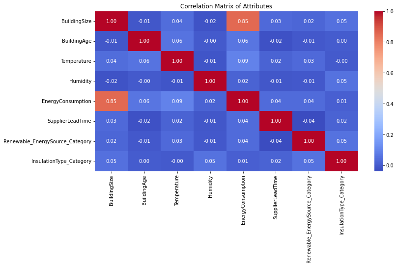

```python
# Finding correlation between attributes using heatmap

correlation_matrix = energy_data.corr(numeric_only=True)

#Plotting

plt.figure(figsize=(12,6))
sns.heatmap(correlation_matrix, annot=True, cmap='coolwarm', fmt='.2f')
plt.title("Correlation Matrix of Attributes")
plt.show()
```

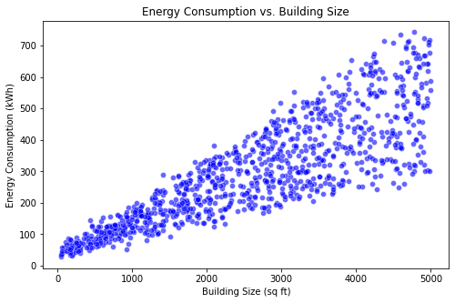

```python
# Energy Consumption vs Building size

plt.figure(figsize=(8, 5))
sns.scatterplot(x='BuildingSize', y='EnergyConsumption', data=energy_data, alpha=0.6, color='blue')
plt.title('Energy Consumption vs. Building Size')
plt.xlabel('Building Size (sq ft)')
plt.ylabel('Energy Consumption (kWh)')
plt.show()
```

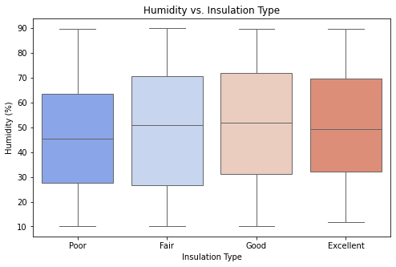

```python
# Humidity vs Insulation Type

plt.figure(figsize=(8, 5))
sns.boxplot(x='InsulationType', y='Humidity', data=energy_data, hue='InsulationType', palette='coolwarm', legend=False)
plt.title('Humidity vs. Insulation Type')
plt.xlabel('Insulation Type')
plt.ylabel('Humidity (%)')
plt.show()
```

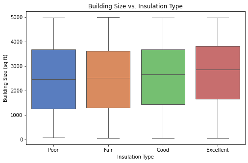

```python
# Building Size vs Insulation Type

plt.figure(figsize=(8, 5))
sns.boxplot(x='InsulationType', y='BuildingSize', data=energy_data, hue='InsulationType', palette='muted', legend=False)
plt.title('Building Size vs. Insulation Type')
plt.xlabel('Insulation Type')
plt.ylabel('Building Size (sq ft)')
plt.show()
```

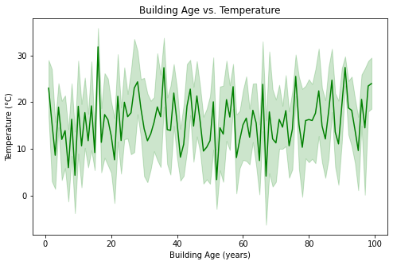

```python
# BuildingAge vs Temperature

plt.figure(figsize=(8, 5))
sns.lineplot(x='BuildingAge', y='Temperature', data=energy_data,color='green')
plt.title('Building Age vs. Temperature')
plt.xlabel('Building Age (years)')
plt.ylabel('Temperature (°C)')
plt.show()
```

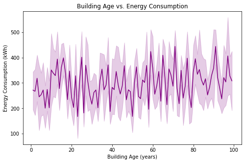

```python
# BuildingAge vs EnergyConsumption

plt.figure(figsize=(8, 5))
sns.lineplot(x='BuildingAge', y='EnergyConsumption', data=energy_data, color='purple')
plt.title('Building Age vs. Energy Consumption')
plt.xlabel('Building Age (years)')
plt.ylabel('Energy Consumption (kWh)')
plt.show()
```

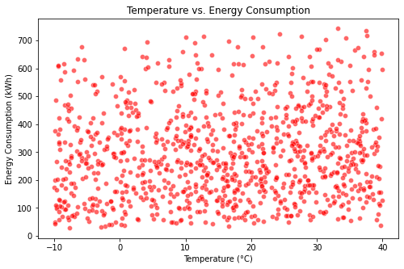

```python
# Temperature vs EnergyConsumption

plt.figure(figsize=(8, 5))
sns.scatterplot(x='Temperature', y='EnergyConsumption', data=energy_data, alpha=0.6, color='red')
plt.title('Temperature vs. Energy Consumption')
plt.xlabel('Temperature (°C)')
plt.ylabel('Energy Consumption (kWh)')
plt.show()
```

# Summary

This report analyzes how buildings consume energy and what factors influence their energy use. It looks at building size, insulation, renewable energy, humidity, temperature, and age to find patterns. The goal is to suggest ways to reduce energy costs and improve energy efficiency.

# Methodology

a) The energy consumption in buildings was cleaned by checking for null, there were null values present in the renewable energy source and the null values were filled with 'None' and there were no duplicates, dropped unecessary columns and converted categorical values into numerical values using label encoding so it could be analyzed properly.

b) Calculated Mean, Median and Standard Deviation Using Descriptive Statistics.

c) To find the co-relation between the attributes used heatmap.

d) Performed Exploratory Data Analysis where visualizations were generated to analyze study the connection between energy consumption, renewable energy source, insulation types, temperature, sixe and age of the buildings

# Key Findings

## Energy Consumption vs. Building Size

Larger buildings tend to consume more energy.

## Building Size vs. Insulation Type

# Recommendations

a) Improve Insulation Efficiency by upgrading in smaller buildings to prevent energy loss.

b) Predict Future Energy Consumption Trends.

c) Optimize Temperature Control.

d) Retrofit old buildings with LED lighting, solar panels, and energy-efficient appliances.

e) Improve ventilation.